# HW 2: Types of Data

# Challenge!!! : Working with SATAN (Optional)

Great job, for not giving up on this subject!

[figure not shown]

Here’s the story: The CSV file that was given to you isn’t just an ordinary file -- it’s data from an organization where Alya-San works!

[figure not shown]

Alya feels that something suspicious is going on within the company. She suspects that there’s inequality in salaries between male and female employees.

She also wonders if the government might be intervening to encourage population growth by secretly increasing the salaries of married employees compared to those who are single.

Additionally, how much of a difference is there in salaries between employees who graduated from different fields of study?

Can you help Alya prove whether her suspicions are just in her head or if they’re actually true?

For Aria, everyone is truly **e q u a l**.

```python
# Implement code here
avg_MonthlyRate_Gender = df.groupby(["Department","Gender"]).agg({
    "MonthlyRate" : "mean"
})
print("Average Monthly Rate by Gender")
print(avg_MonthlyRate_Gender)
```

```
Average Monthly Rate by Gender
                                MonthlyRate
Department             Gender
Human Resources        Female  14410.500000
                       Male    13066.232558
Research & Development Female  14932.350923
                       Male    13863.221649
Sales                  Female  14185.682540
                       Male    14713.439689
```

```python
avg_MonthlyRate_Edu = df.groupby(["Department","EducationField"]).agg({
    "MonthlyRate" : "mean"
})
print("Average Monthly Rate by Education Field")

print(avg_MonthlyRate_Edu)
```

```
Average Monthly Rate by Education Field
                                          MonthlyRate
Department             EducationField
Human Resources        Human Resources   14810.740741
                       Life Sciences     12813.875000
                       Medical           12668.230769
                       Other              9275.000000
                       Technical Degree  13158.500000
Research & Development Life Sciences     14594.704545
                       Medical           14163.603306
                       Other             13051.765625
                       Technical Degree  14142.393617
Sales                  Life Sciences     14523.786667
                       Marketing         14076.943396
                       Medical           15077.625000
                       Other             15004.400000
                       Technical Degree  14522.029412
```

```python
avg_MonthlyRate_MaritalStatus = df.groupby(["Department","MaritalStatus"]).agg({
    "MonthlyRate" : "mean"
})
print("Average Monthly Rate by Marital Status")
print(avg_MonthlyRate_MaritalStatus)
```

```
Average Monthly Rate by Marital Status
                                       MonthlyRate
Department             MaritalStatus
Human Resources        Divorced       14277.125000
                       Married        13010.588235
                       Single         13789.538462
Research & Development Divorced       14337.553571
                       Married        13981.224018
                       Single         14678.532895
Sales                  Divorced       14245.425287
                       Married        14348.155340
                       Single         14819.450980
```

Since Kobayashi-san will be reviewing your code, please present the data in a way that is clear and accurate. Otherwise, Kobayashi-san might fire you from the company!

[figure not shown]

[figure not shown]

```python
# Write your code here
chart_data = avg_MonthlyRate_Gender.unstack()
chart_data.plot(kind='bar', figsize=(10, 6))

plt.title('Monthly Rate: Department and Gender')
plt.ylabel('Average Monthly Rate')
plt.xlabel('Department')
plt.xticks(rotation=45)
plt.legend(title='Marital Status')
plt.grid(axis='y', linestyle='--', alpha=0.7)

plt.show()
```

[figure not shown]

```python
chart_data = avg_MonthlyRate_Edu.unstack()
chart_data.plot(kind='bar', figsize=(10, 6))

plt.title('Monthly Rate: Department and Education Field')
plt.ylabel('Average Monthly Rate')
plt.xlabel('Department')
plt.xticks(rotation=45)
plt.legend(title='Marital Status')
plt.grid(axis='y', linestyle='--', alpha=0.7)

plt.show()
```

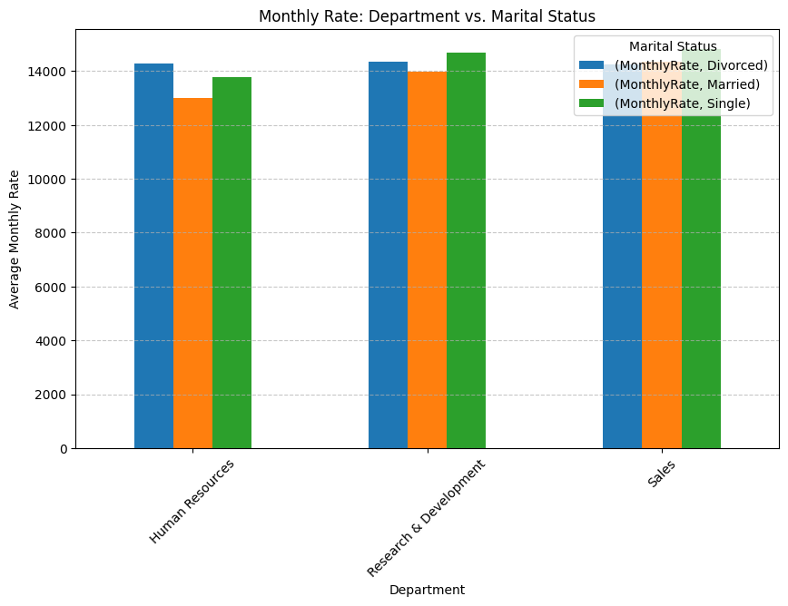

```python
chart_data = avg_MonthlyRate_MaritalStatus.unstack()
chart_data.plot(kind='bar', figsize=(10, 6))

plt.title('Monthly Rate: Department vs. Marital Status')
plt.ylabel('Average Monthly Rate')
plt.xlabel('Department')
plt.xticks(rotation=45)
plt.legend(title='Marital Status')
plt.grid(axis='y', linestyle='--', alpha=0.7)

plt.show()
```